# Diamond Supplier Report

Andrew Engellant

11 March, 2024

## Introduction

In business, a common saying is “no good deed goes unpunished,” humorously noting how success in one area often leads to increased expectations in others. This has been your experience after your comparative analysis revealed that Supplier B’s prices were reasonable, considering they supplied larger diamonds than Suppliers A and C.

Your boss, the director of product analytics, loved the analysis where you uncovered that Supplier B’s prices were fair, it’s just that they had larger diamonds than A and C. And she shared that analysis with the product managers of a few different verticals and the full jewelry team.

Responding to this interest, you are tasked with demystifying your findings and the underpinning model—referred to as `lm_final`—for a broader audience, particularly the jewelry team. Teamed up with a seasoned data scientist, you’ve refined `lm_final` to not only satisfy statistical rigor but also cater to practical business insights.

This assignment challenges you to translate the complex facets of your analysis into insights that resonate with non-experts. It’s an exercise in bridging data science with business acumen, honing your ability to communicate technical findings in an accessible manner. Whether through a detailed report or presentation, your goal is to illuminate the intriguing patterns and implications discovered through your analysis. Use the principles discussed in this week’s lecture to respond to specific questions outlined below, ensuring clarity and thoroughness in your explanations.

## Model Building

```r
# Convert to factors
d <- d %>%
  mutate(
    clarity = fct_reorder(clarity,price),
    cut = fct_reorder(cut,price),
    color = fct_reorder(color,price)
  )

# To make life easier, let's collapse clarity and color to fewer levels
d <- d %>%
  mutate(
    grp_clarity = case_when(
      clarity %in% c("IF", "VVS1", "VVS2") ~ "High Clarity",
      clarity %in% c("VS1", "VS2") ~ "Medium Clarity",
      clarity %in% c("SI1", "SI2", "I1") ~ "Low Clarity",
      TRUE ~ as.character(clarity)  # This line handles any unexpected categories
    ),
    grp_color = case_when(
      color %in% c("D", "E") ~ "High Color",
      color %in% c("F", "G") ~ "Medium Color",
      color %in% c("H", "I", "J") ~ "Low Color"
    )
  ) %>%
  mutate(grp_color = fct_reorder(grp_color,price),
         grp_clarity = fct_reorder(grp_clarity,price))


# This could have been your original model
lm_base <- lm(price ~ grp_clarity + grp_color + cut + carat + supplier ,
              data=d)

# And here's the final model you came up with. This model balances
# the needs of the business with statistical accuracy.
lm_final <- lm(price ~ grp_clarity*grp_color + grp_color*carat + cut + supplier,
          data=d)

#anova(lm_base,lm_final)
```

## Model Explanation

### Model Analysis

```r
library(arm)
display(lm_final)
```

```
## lm(formula = price ~ grp_clarity * grp_color + grp_color * carat +
##     cut + supplier, data = d)
##                                                 coef.est coef.se
## (Intercept)                                     -1423.12    28.65
## grp_clarityMedium Clarity                        -976.86    28.82
## grp_clarityLow Clarity                          -2046.18    29.09
## grp_colorMedium Color                            -550.07    34.57
## grp_colorLow Color                               -569.32    38.23
## carat                                            9130.25    28.26
## cutVery Good                                     -160.48    14.21
## cutGood                                          -410.54    19.87
## cutPremium                                       -163.27    13.81
## cutFair                                         -1420.42    32.43
## supplierSupplier B                                -32.51    17.21
## supplierSupplier C                                  5.25    11.65
## grp_clarityMedium Clarity:grp_colorMedium Color   306.14    36.48
## grp_clarityLow Clarity:grp_colorMedium Color     -160.88    37.39
## grp_clarityMedium Clarity:grp_colorLow Color      535.91    41.35
## grp_clarityLow Clarity:grp_colorLow Color         690.41    41.78
## grp_colorMedium Color:carat                       219.22    35.29
## grp_colorLow Color:carat                        -1276.43    33.51
## ---
## n = 53940, k = 18
## residual sd = 1239.39, R-Squared = 0.90
```

```r
anova(lm_final)
```

```
## Analysis of Variance Table
##
## Response: price
##                          Df     Sum Sq    Mean Sq    F value Pr(>F)
## grp_clarity               2 1.5696e+10 7.8481e+09 5.1092e+03 <2e-16 ***
## grp_color                 2 2.4200e+10 1.2100e+10 7.8771e+03 <2e-16 ***
## carat                     1 7.2723e+11 7.2723e+11 4.7343e+05 <2e-16 ***
## cut                       4 3.1673e+09 7.9183e+08 5.1549e+02 <2e-16 ***
## supplier                  2 1.2691e+06 6.3454e+05 4.1310e-01 0.6616
## grp_clarity:grp_color     4 4.1491e+08 1.0373e+08 6.7527e+01 <2e-16 ***
## grp_color:carat           2 4.9348e+09 2.4674e+09 1.6063e+03 <2e-16 ***
## Residuals             53922 8.2828e+10 1.5361e+06
## ---
## Signif. codes:  0 '***' 0.001 '**' 0.01 '*' 0.05 '.' 0.1 ' ' 1
```

#### 1. Overall Assessment of Model Performance

This model does an excellent job of predicting the cost of a diamond from each supplier based on the diamond’s size, cut, color, and clarity. This model typically predicts within $1,240 of the true price of a diamond, and an impressive 90% of the total variation in diamond prices can be explained using these variables alone.

#### 2. Explaination of “Cut” Coefficient

The cut of a diamond can have substantial effects on the price of the diamond. Diamonds with an **Ideal** cut are typically priced $1,420 higher than diamonds with a **Fair** cut and $410 higher than diamonds with a **Good** cut. Interestingly, both **Very Good** and **Premium** cut diamonds are priced about $160 less than diamonds with an **Ideal** cut, but there appears to be no significant difference between prices of **Very Good** and **Premium** cut diamonds.

#### 3. How do Color and Carat Interact?

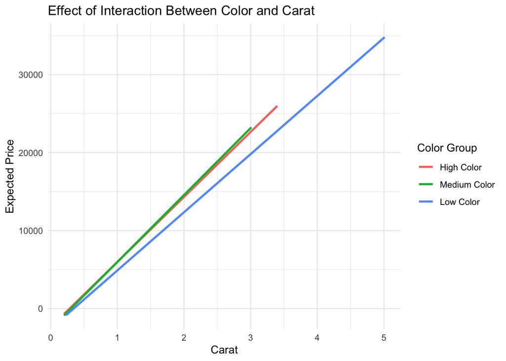

```r
new_data <- d %>%
  expand_grid(
    new_grp_color = unique(d$grp_color),
    new_carat = 1:3
)

new_data <- d %>%
         mutate(price = predict(lm_final, d))

ggplot(new_data,
       aes(x=carat, y=price, color = grp_color)) +
  geom_smooth(method = "lm", se = FALSE) +
  theme_minimal() +
  labs(x="Carat",
       y="Expected Price",
       title="Effect of Interaction Between Color and Carat",
       color = "Color Group")
```

The coefficients for this model suggest that a one carat increase in diamond size has about a $220 higher increase in expected price for diamonds of medium color compared to diamonds of high color. The expected price of diamonds of low color, however, increase by roughly $1200 less than diamonds of high color for each unit increase in carat size. Carat size has a greater impact on expected price when the diamonds have medium or high color. The above plot displays the effects on expected price for each group of diamond color as carat size increases. The medium and high color diamonds (green and red lines respectively) have steeper slopes than the low color diamonds (blue line) so their expected price increases more rapidly as carat size increases.

#### 4. How do color and clarity interact?

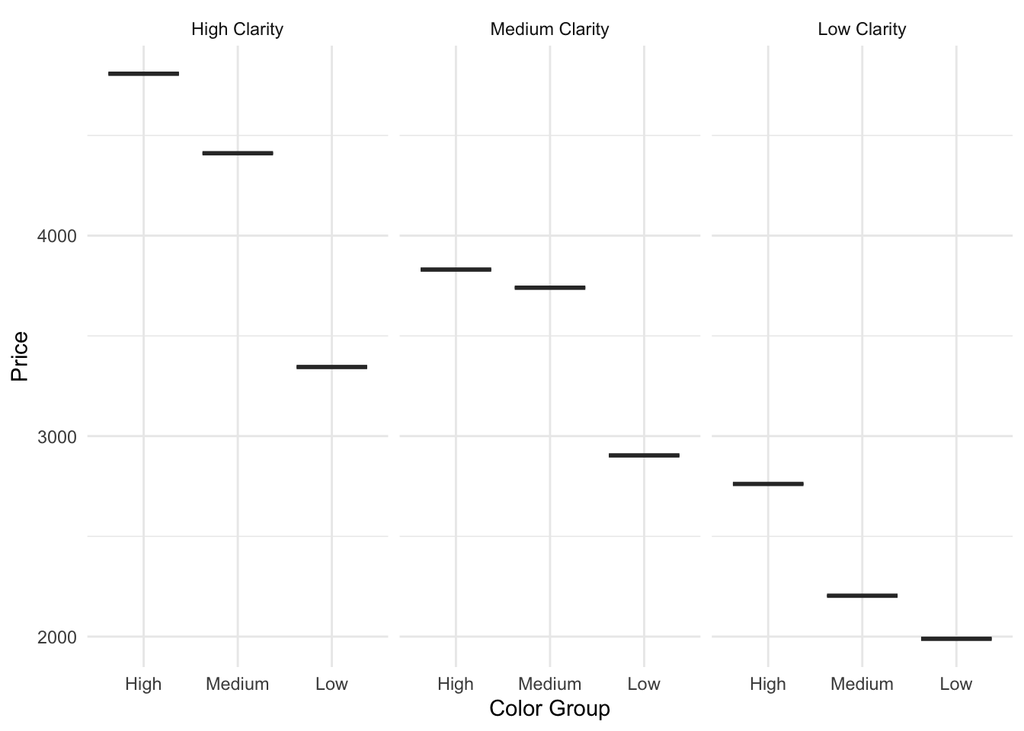

```r
# Create data for the plot
plot_data <- expand.grid(
  grp_color = unique(d$grp_color),
  grp_clarity = unique(d$grp_clarity),
  carat = median(d$carat),
  cut = 'Very Good',
  supplier = 'Supplier A'
)

#Add in predicted price
plot_data$price <- predict(lm_final, newdata = plot_data)

# Plot data
custom_labels <- c("High Color" = "High", "Medium Color" = "Medium", "Low Color" = "Low")

ggplot(plot_data, aes(x = factor(grp_color, labels = custom_labels), y = price)) +
  geom_boxplot() +
  facet_wrap(~grp_clarity) +
  labs(x = "Color Group", y = "Price") +
  scale_x_discrete(labels = custom_labels) +
  theme_minimal()
```

The above plot displays the interaction between group color and group clarity, and their effects on predicted price for an ‘average diamond’. It’s expected that the price will decrease as clarity decreases, just as displayed above. What’s interesting is how the price changes differently between color groups when the clarity is different. For instance, the price of a low color diamond is significantly less than a medium colored diamond when the clarity is high, but is comparable when the the clarity is low. Also, the difference in price between high color and medium color diamonds is significant when the clarity is high or low, but is small for diamonds with medium clarity. Overall, changes in color group have the greatest impact on diamonds that have high clarity.

#### 5. How Important are the Interaction Terms

```r
anova(lm_final)
```

```
## Analysis of Variance Table
##
## Response: price
##                          Df     Sum Sq    Mean Sq    F value Pr(>F)
## grp_clarity               2 1.5696e+10 7.8481e+09 5.1092e+03 <2e-16 ***
## grp_color                 2 2.4200e+10 1.2100e+10 7.8771e+03 <2e-16 ***
## carat                     1 7.2723e+11 7.2723e+11 4.7343e+05 <2e-16 ***
## cut                       4 3.1673e+09 7.9183e+08 5.1549e+02 <2e-16 ***
## supplier                  2 1.2691e+06 6.3454e+05 4.1310e-01 0.6616
## grp_clarity:grp_color     4 4.1491e+08 1.0373e+08 6.7527e+01 <2e-16 ***
## grp_color:carat           2 4.9348e+09 2.4674e+09 1.6063e+03 <2e-16 ***
## Residuals             53922 8.2828e+10 1.5361e+06
## ---
## Signif. codes:  0 '***' 0.001 '**' 0.01 '*' 0.05 '.' 0.1 ' ' 1
```

The interaction between group color and carat plays an large role in determining the price of a diamond. The F value in the table above displays this importance. The higher the F value, the greater the influence the variable has on the model’s prediction of a diamond’s price. We should also note the Pr(>F) values, which indicate the significance of each F value, but both interaction terms are highly significant so we can ignore this portion. The interaction between group clarity and group color plays a small role in this model, but not nearly as important as the interaction between group color and carat.

#### 6. Ignoring carat, what aspect of a diamond is the most important to determining price?

Again, looking at the F values from the table above, we can see that carat plays the most important role in determining diamond price. If we ignore this variable, however, the next most important aspects are group color and group clarity. These variable have the next highest F values and therefore do a better job of predicting the variance in price than other variables like cut and supplier.

Interestingly, each of these two variables independently play large roles in determining price, but the interaction between them has little impact. This means that the value of a diamond still increases from medium to high color and from medium to high clarity, but the presence of both high color and high clarity is not considered more rare than either occurring alone.

#### 7. Testing on a holdout sample

Let’s refit the model on a sample of the data so that we can assess performance on the portion that’s held out.

```r
set.seed(20240301)

training_idx <- sample(nrow(d),size=round(nrow(d)*0.75),replace=F)
testing_idx <- (1:nrow(d))[!(1:nrow(d)) %in% training_idx]
training_data <- d[training_idx,]
testing_data <- d[testing_idx,]

refit_final <- update(lm_final,data=training_data)

testing_data <- testing_data %>%
  mutate(pred_price = predict(refit_final, newdata = testing_data))

testing_data <- testing_data %>%
  mutate(residuals = price - pred_price)

# Calculate the sum of squares of residuals (RSS)
SS_res <- sum(testing_data$residuals^2)

# Calculate the mean of the observed values
mean_observed <- mean(testing_data$price)

# Calculate the total sum of squares (TSS)
SS_tot <- sum((testing_data$price - mean_observed)^2)

# Calculate R-squared
R_squared <- 1 - (SS_res / SS_tot)

R_squared
```

```
## [1] 0.9052143
```

```r
# Calculate the residual standard error (RSE)
n <- nrow(testing_data)  # Number of observations
p <- length(coef(refit_final)) - 1  # Number of coefficients (excluding intercept)
RSE <- sqrt(sum(testing_data$residuals^2) / (n - p - 1))

RSE
```

```
## [1] 1238.082
```

The model did an excellent job of predicting the price of the diamonds in our test data set. Over 90% of the variation in diamond price was predicted by this model, and the average prediction was about $1200 away from the true price of the diamond.

```r
# Sort the data frame based on the absolute values of the residuals
sorted_data <- testing_data[order(testing_data$residuals, decreasing = TRUE), c("price", "pred_price", "carat", "grp_color", "grp_clarity", "cut")]

# Print the top five rows with the highest residuals
head(sorted_data, 8)
```

```
## # A tibble: 8 × 6
##   price pred_price carat grp_color  grp_clarity  cut
##   <dbl>      <dbl> <dbl> <fct>      <fct>        <fct>
## 1 16469      7701.  1    High Color High Clarity Ideal
## 2 17042      8315.  1.07 High Color High Clarity Ideal
## 3 16087      7636.  1.01 High Color High Clarity Very Good
## 4 18700     10254.  1.28 High Color High Clarity Ideal
## 5 16406      8095.  1.09 High Color High Clarity Good
## 6 15081      7343.  1.01 High Color High Clarity Good
## 7 17192      9454.  1.21 High Color High Clarity Premium
## 8 15306      7725.  1.02 High Color High Clarity Very Good
```

Our model tends to underestimate the price of 1 carat diamonds that have both High Color and High Clarity. The 8 diamonds with the worst underestimates can be seen above.

```r
sorted_data <- testing_data[order(testing_data$residuals, decreasing = FALSE), c("price", "pred_price", "carat", "grp_color", "grp_clarity", "cut")]

# Print the top five rows with the highest residuals
head(sorted_data, 8)
```

```
## # A tibble: 8 × 6
##   price pred_price carat grp_color    grp_clarity cut
##   <dbl>      <dbl> <dbl> <fct>        <fct>       <fct>
## 1 18018     34631.  5.01 Low Color    Low Clarity Fair
## 2 15223     28003.  4.01 Low Color    Low Clarity Premium
## 3  8040     20160.  3.01 Low Color    Low Clarity Premium
## 4  8044     18838.  3    Low Color    Low Clarity Fair
## 5  7226     17073.  2.3  Medium Color Low Clarity Premium
## 6 12545     21975.  3.22 Low Color    Low Clarity Ideal
## 7  7131     15554.  2.27 Medium Color Low Clarity Fair
## 8 10577     18995.  3.02 Low Color    Low Clarity Fair
```

This model tends to overestimate the price of high carat diamonds that have both Low Color and Low Clarity. The 8 diamonds with the worst overestimates can be seen above.

```r
sorted_data <- testing_data[order(abs(testing_data$residuals), decreasing = FALSE), c("price", "pred_price", "carat", "grp_color", "grp_clarity", "cut")]

# Print the top five rows with the highest residuals
head(sorted_data, 8)
```

```
## # A tibble: 8 × 6
##   price pred_price carat grp_color    grp_clarity    cut
##   <dbl>      <dbl> <dbl> <fct>        <fct>          <fct>
## 1   766       766.  0.38 Medium Color Medium Clarity Very Good
## 2   766       766.  0.38 Medium Color Medium Clarity Very Good
## 3  1982      1982.  0.7  Low Color    Low Clarity    Premium
## 4  8545      8545.  1.2  Medium Color Medium Clarity Ideal
## 5  2377      2377.  0.73 Low Color    Low Clarity    Ideal
## 6   778       777.  0.31 Medium Color High Clarity   Very Good
## 7  6618      6619.  1.01 Medium Color Medium Clarity Premium
## 8  6618      6619.  1.01 Medium Color Medium Clarity Premium
```

## Appendix: Description of the Diamonds Dataset

Our diamonds dataset is a comprehensive collection diamond data from our suppliers, representing various attributes of a large number of diamonds. The dataset includes the following attributes:

- `Carat`: Numeric. Represents the weight of the diamond, measured in carats. A higher carat number indicates a heavier diamond.
- `Cut`: Categorical. Indicates the quality of the cut of the diamond, which affects its symmetry, brightness, and overall appearance. The categories include Fair, Good, Very Good, Premium, and Ideal, with Ideal being the highest quality.
- `Color`: Categorical. Denotes the color grade of the diamond, which ranges from J (lowest grade, more color) to D (highest grade, colorless). The grading scale moves from a noticeable color to colorless.
- `Clarity`: Categorical. Describes the clarity of the diamond, which refers to the absence of inclusions and blemishes. The categories range from I1 (Inclusions 1, lowest clarity) to IF (Internally Flawless, highest clarity).
- `Depth`: Numeric. The depth percentage of the diamond, calculated as the ratio of the diamond’s total depth (from table to culet) to its average diameter.
- `Table`: Numeric. Refers to the width of the top facet of the diamond, known as the table, relative to the widest point of the diamond. It is expressed as a percentage.
- `Price`: Numeric. The price of the diamond in US dollars.
- `X`: Numeric. The length of the diamond in millimeters.
- `Y`: Numeric. The width of the diamond in millimeters.
- `Z`: Numeric. The depth of the diamond in millimeters.
- `Supplier`: Categorical. Represents the supplier of the diamonds to a major online marketplace (e.g., Amazon). Each diamond is sourced from one of several suppliers, each with varying reputations and qualities of service. The suppliers are anonymized and labeled as “Supplier A”, “Supplier B”, “Supplier C”, etc.